# A current affair: entanglement of humpback whales in coastal shark‐control nets - Bolin - 2020 - Remote Sensing in Ecology and Conservation - Wiley Online Library

Original Research

Open Access

# A current affair: entanglement of humpback whales in coastal shark‐control nets

[Jessica A. Bolin](https://zslpublications.onlinelibrary.wiley.com/action/doSearch?ContribAuthorStored=Bolin%2C+Jessica+A)

[David S. Schoeman](https://zslpublications.onlinelibrary.wiley.com/action/doSearch?ContribAuthorStored=Schoeman%2C+David+S)

[Carme Pizà‐Roca](https://zslpublications.onlinelibrary.wiley.com/action/doSearch?ContribAuthorStored=Piz%C3%A0-Roca%2C+Carme)

[Kylie L. Scales](https://zslpublications.onlinelibrary.wiley.com/action/doSearch?ContribAuthorStored=Scales%2C+Kylie+L)

First published: 21 November 2019

https://doi.org/10.1002/rse2.133

## Abstract

Shark‐control nets pose an entanglement risk to East Australian humpback whales during their annual northward and southward migrations between the Southern Ocean and the Coral Sea. Rates of whale entanglement exhibit seasonal and interannual variation, suggesting that an understanding of the influence of variability in the broad‐scale physical environment along the migratory route would be useful in assessing risk of entanglement. This study provides a quantitative spatio‐temporal analysis of the probability of whale entanglement in shark‐control nets relative to the position and characteristics of the East Australian Current (EAC), the dominant oceanographic feature of the region. We use satellite‐derived sea‐surface temperature, and outputs from a data‐assimilating ocean model, to develop multivariate, data‐driven algorithms for detecting the edge of the EAC using Principal Components Analysis. We use outputs from these algorithms to model the likelihood of humpback entanglements in South‐east Queensland. We find that the likelihood of entanglement increases when the EAC edge is locally less structured and closer to shore in the vicinity of the corresponding net, or when the EAC is well resolved over the entire study domain. Our results suggest that migrating humpbacks use the gradient in physical characteristics that marks the EAC inner edge as a navigational aid. Thus, when the EAC inner edge encroaches on the coast, the whales’ migration range is compressed into nearshore waters, increasing the risk of entanglement. Our findings can help predict periods of elevated entanglement risk, which could underpin a more data‐driven approach to the management of shark‐control programs, and other activities that involve static fishing gear.

## Introduction

Humpback whales, *Megaptera novaeangliae*, are a wide‐ranging, migratory marine species that can travel across ocean basins, and a variety of political domains (Harrison et al. 2018). The global humpback whale population is currently recovering from the cessation of commercial whaling, with some regional populations now at historical carrying capacity (Noad et al. 2011). In fact, the east Australian (substock E1) population is experiencing a rapid population recovery of around 11% per annum (Noad et al. 2019). The trend toward increasing numbers of humpback whales has been matched by an escalation in the anthropogenic use of coastal waters (Maxwell et al. 2013; Halpern et al. 2015) for activities such as commercial fishing and shipping (Thomas et al. 2016; Pirotta et al. 2019). Humpbacks often use coastal waters as migratory corridors (García‐Godos et al. 2013; Peel et al. 2018), thereby creating the potential for whale‐human interactions such as entanglements in fishing gear and ship strikes, often with adverse outcomes for the whales. This complicates population‐level conservation and management of humpback whales.

Humpbacks exhibit well‐developed navigational abilities, and high route fidelity when travelling across the open ocean (Horton et al. 2017) or along routes during annual breeding migrations (Bruce et al. 2014). Yet, an understanding of the mechanisms that underlie whale navigation remains poorly developed. In common with other marine predators, movement decisions are likely driven by the interplay between intrinsic factors, such as spatial memory and breeding cycles, and responses to contemporaneous environmental cues such as coastal landmarks, physical features of the water column or underwater sound (Horton et al. 2011; Geijer et al. 2016; Hays et al. 2016; Abrahms et al. 2019).

East Australian humpback whales undertake highly predictable annual migrations from their feeding grounds in the Southern Ocean, to tropical breeding grounds in the Coral Sea. Along the Australian east coast, humpbacks tend to pass within 10–30 km of the shore (Noad et al. 2011; Harcourt et al. 2014). However, individuals from other populations have been shown to deviate from predictable migratory corridors by as much as 150 km (Horton et al. 2017). Any spatial variability in the migratory route taken can strongly influence the likelihood of interaction with anthropogenic threats, particularly in the coastal zone.

Here, we propose that humpbacks respond to variability in the physical environment, using the inner edge of the East Australian Current (EAC) as a navigational aid. The EAC is an oligotrophic western boundary current that closes the South Pacific subtropical gyre, and brings warm, tropical water poleward (Suthers et al. 2011). A characteristic feature of the EAC is its variability, with a strong seasonal cycle in velocity and transport volume (Ridgway and Godfrey 1997). Whilst the core of the EAC generally follows the continental slope, the inner and outer edges of this current frequently meander (Bull et al. 2017). Under natural conditions, a strategy of following linear discontinuities such as the EAC inner edge would allow migrating humpbacks to optimize navigational efficiency by preventing them from straying from their migratory corridor (Reinke et al. 2016). However, given the anthropogenic modification of nearshore waters, which has introduced potential hazards, such behaviour could be considered maladaptive.

Of all coastal hazards, humpbacks are particularly vulnerable to entanglement in gillnets (Thomas et al. 2016), which are used both in fisheries and in shark‐control programs. Since 1962, the Queensland Shark Control Program (QSCP) has used permanent surface‐set gillnets (hereafter shark‐control nets) to reduce the population size of large sharks at popular beaches (Cliff and Dudley 2011). Shark‐control nets are passive devices (Sumpton et al. 2011), known to be a threat to a wide range of species, including turtles, finfish, rays, dolphins and humpback whales, especially during the whale migration season (Volep et al. 2017).

We use a data‐driven approach to quantify the potential effects of sea‐surface temperature (SST), the position of the inner edge of the EAC and the overall structure of the current, on the probability of humpback whale entanglements in QSCP shark‐control nets. Using satellite‐derived measures of the physical ocean, we aim to (i) quantify the physical characteristics of the EAC inner edge at daily time intervals, and (ii) determine the relative risk of entanglement of humpback whales in shark‐control nets, dependent on the position and characteristics of the EAC inner edge.

## Materials and Methods

### Study area

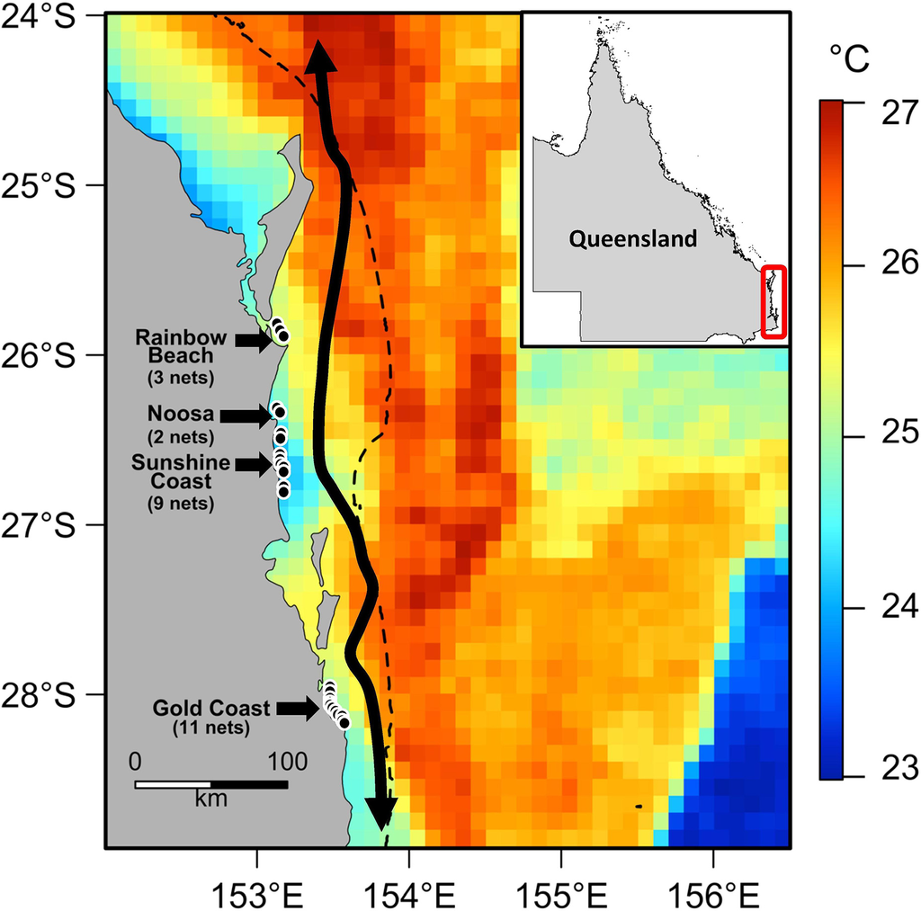

**Figure 1**

### Entanglements in shark‐control nets

Yearly entanglement records were obtained from the data portal of Queensland Department of Fisheries Shark Control Program (https://data.qld.gov.au/dataset/shark-control-program-non-target-statistics-by-year). Whilst cetacean entanglement records exist from 1968, the analysis was restricted to 2001–2017 because earlier records often did not identify the species entangled. Although nets are routinely checked by contractors every two or three days, the marine animal release team is deployed immediately on detection of a humpback whale entanglement. Therefore, we are confident that the dates in the humpback entanglement records reflected the true date of entanglement and not subsequent service runs to check nets for entanglements. Records included 56 humpback whale entanglements. However, three days had multiple entanglement incidences, resulting in 53 entanglement‐positive days.

### Environmental data

To explore the variability of ocean circulation in SEQ, we obtained daily ocean reanalysis data from BlueLink Reanalysis version 3.5 (BRAN3p5). This included meridional velocity (VCUR) (m/s), current speed (m/s) and temperature (°C) for the upper 5 m of the water column, all between 2001 and 2017. BRAN3p5 assimilates altimetry, SST, Argo temperature and salinity data using the BlueLink Ocean Data Assimilation System (BODAS), and has a resolution of 10 km. These data realistically represent the regional oceanography of the study area (Ismail et al. 2017). We derived the daily sea‐surface temperature (SST) at each site by aggregating 1‐km NASA Multi‐sensor Ultra‐high Resolution Sea‐Surface Temperature data (MUR SST) to 10‐km resolution by the mean, to match the resolution of BRAN3p5. To derive corresponding data for the first year of our study, we also aggregated 2‐km resolution Advanced Very High Resolution Radiometer (AVHRR) data, provided by the Integrated Marine Observing System (IMOS), from 2001‐05‐01 to 2002‐05‐30 to 10‐km. When cloud cover contaminated the daily AVHRR‐SST data, we used a three‐day SST average, centred on the day of interest. All spatial manipulation and extractions were done in the ‘raster’ package for R (R Core Team 2016; Hijmans 2017).

### Mapping the East Australian Current

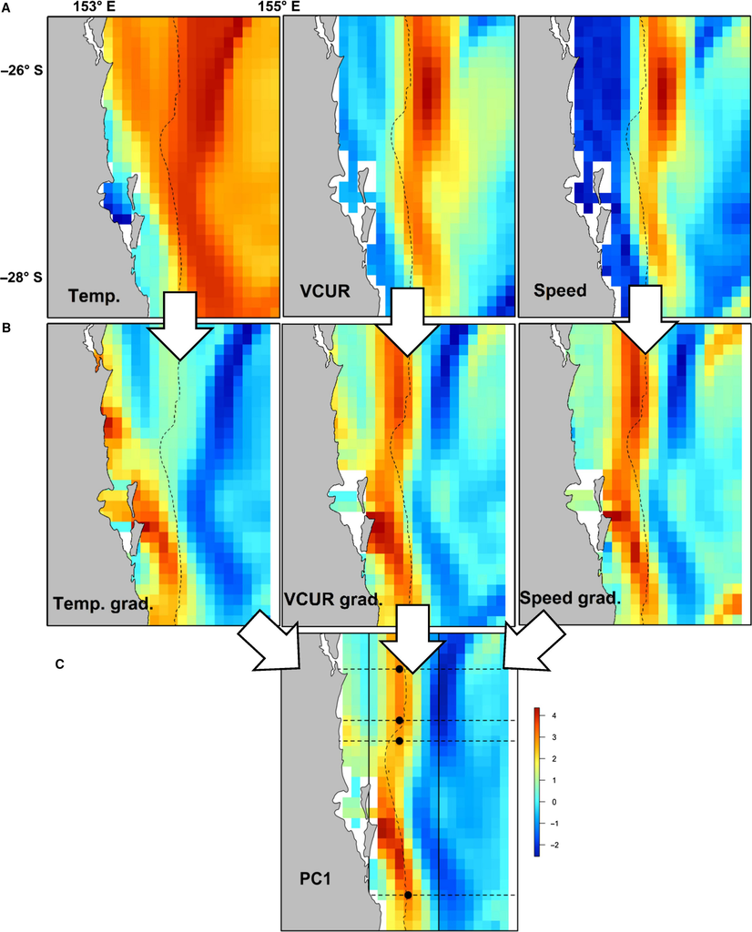

**Figure 2**

As explained above, input data (gradients) were configured to increase at the EAC inner edge, so positive loadings of the variables onto PC1 implied that the PC1 values increased as the input values increase. Therefore, when variables’ loadings on the PC1 were all negative, the values of PC1 were multiplied by ‐1 to ensure consistency of interpretation. In some cases, however, the signs of the loadings did not concur; in these cases, we recorded the PCA as a ‘failure’, because it was unable to resolve the EAC on the basis of consistent gradients in the input data.

The EAC inner edge is characterized by strong on‐offshore gradients of temperature, VCUR and speed. For this reason, we used the maximum value of PC1 at any given latitude, which indicates the maximum rate of on‐offshore change (i.e., gradient) in combined variables, as a proxy for the location of the inner edge of the EAC at that latitude, and refer to this value as the ‘maximum environmental gradient’. As such, the magnitude of the maximum environmental gradient quantifies the sharpness or resolution with which the edge of the EAC can be resolved for any point along the coast. Given that the EAC inner edge is assumed to generally run close to the continental shelf, we constrained the search for the maximum environmental gradient between 153.45 ˚E and 154. 25 ˚E, thereby excluding confounding features of estuaries and embayments to the inshore side and oceanic waters offshore. From within this longitudinal range, the position of the maximum environmental gradient value was extracted at the latitude of each shark‐control net site, indicating the location of the inner edge of the EAC. These points were also used to estimate the distance of the EAC inner edge from each shark‐control net site. For each day, we also recorded the variance explained by PC1. When this value is high, the EAC is well‐defined over the study domain. Finally, the SSTs of the inner edge were also extracted from corresponding MUR SST or AVHRR SST data layers for each shark‐control net location.

### Statistical analysis

Table 1. Modelling the influence of the East Australian Current (EAC) inner edge on entanglement

| Predictor (standardized) | Median and range of 1000 regression coefficients |
| --- | --- |
| *a. SST of shark‐control net metric* |  |
| SST of net (˚C) | −0.002 −0.096 to 0.094 |
| *b. EAC edge metrics* |  |
| Distance to edge (km) | −0.181 −0.314 to −0.063 |
| SST of edge (˚C) | 0.039 −0.057 to 0.144 |
| Maximum environmental gradient | −0.329 −0.446 to −0.223 |
| Variance (variance explained by first principle component) | 0.11 0.013 to 0.204 |

## Results

### PCA methodology

Of the 53 total entanglements, three entanglements corresponded with the three days in which the PCA was a ‘failure’ for detection of the EAC edge in that particular day (Table S4). This represented 5.6% of entanglements and 2.8% of ‘failure’ PCAs (106 days). Given the similarly small proportions, we discounted the possibility that a complete breakdown of the surface structure of the EAC (i.e., the PCA failed to resolve its spatial pattern) was responsible for entanglements.

### East Australian current

When accounting for site effects and fishing effort, SST at the shark‐control net did not significantly influence the probability of humpback whale entanglement (Fig. 3A, Table 1a).

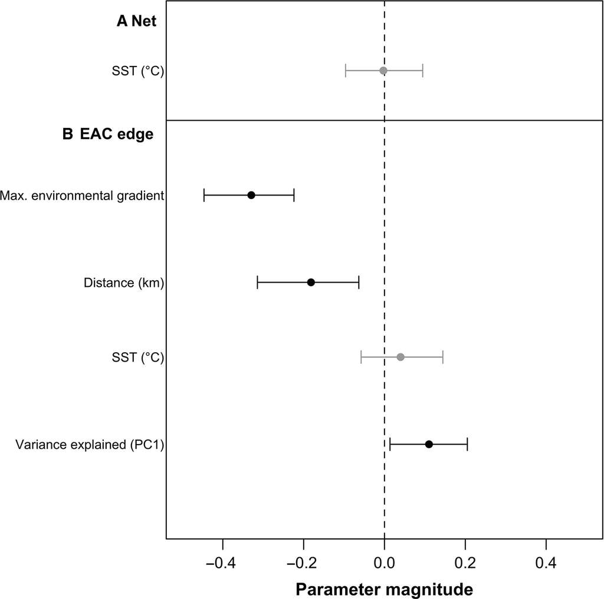

**Figure 3**

Distributions of parameter estimates from 1000 models fit to subsets of data comprising all observed entanglements and a random sub‐sample of ~220 days on which entanglements were not observed. Metrics relating to (A) the shark‐control net, and (B) the East Australian Current (EAC) inner edge. To ensure comparability of the magnitudes of parameter estimates, all predictors were scaled to a mean of zero and unit variance prior to analysis. Filled circles indicate medians of estimates, and 95% confidence intervals are shown as horizontal lines. Non‐significant parameter distributions are coloured in grey.

By contrast, the maximum environmental gradient at the EAC edge, the distance from the inner edge of the EAC to the shark‐control net and variance explained by PC1 were significant predictors of humpback whale entanglement (Fig. 3B, Table 1b). Entanglements were more likely to occur when the maximum environmental gradient at the EAC edge adjacent to the shark‐control net was smaller, when the EAC edge was closer to the shark‐control net, and when variance explained by PC1 over the whole study domain was higher (Fig. 4A–C). SST of the EAC edge was not a significant predictor of entanglement (Fig. 3B).

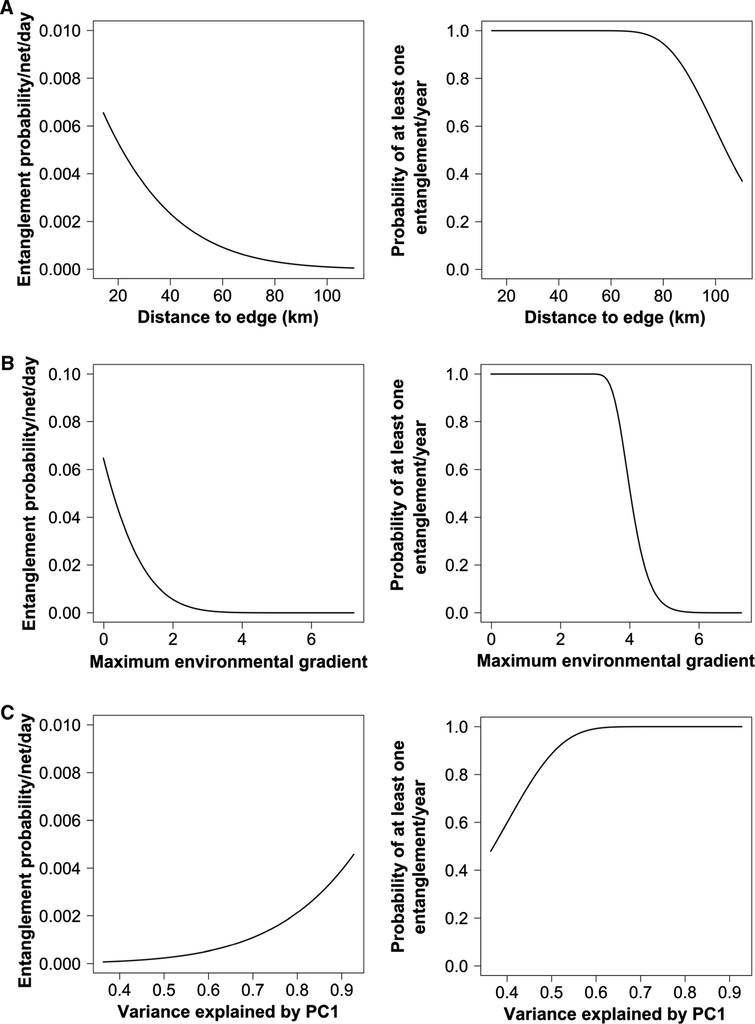

**Figure 4**

## Discussion

Migratory marine predators traverse vast, dynamic seascapes through ontogenetic and annual breeding cycles. The mechanisms underlying the abilities of these migratory species to navigate remain largely obscure, but several species, including birds, mammals, reptiles, fish, insects and plankton, are known to use a scale‐nested combination of spatial memory, and real‐time responses to contemporaneous physical cues (Horton et al. 2011; Geijer et al. 2016; Hays et al. 2016; Abrahms et al. 2019). Our findings demonstrate that the migratory path of East Australian (E1) humpback whales is associated with the position and character of the East Australian Current inner edge. This significantly influences the likelihood of entanglement of humpbacks in nearshore shark‐control nets, which is both a threat to the welfare of individual whales, and a significantly negative influence on public perception of the shark‐control program in Australia.

Marine predators of multiple taxa are known to associate with environmental gradients across a range of spatial scales (Miller et al. 2015; Scales et al. 2015, 2018). There are two known mechanisms underpinning associations between marine vertebrates and frontal gradients: foraging and navigation. Humpbacks are known to forage along the inner edge of the broad‐scale upwelling front in the Northern California Current System (Tynan et al. 2005), the boundary of the Antarctic Circumpolar Current (Tynan 1998) and along (sub‐)mesoscale thermal fronts in coastal British Columbia (Dalla Rosa et al. 2012). More recently, humpbacks have been found to associate with fine‐scale thermal fronts in the Gold Coast Bay (Reinke et al. 2016). We hypothesize that humpbacks in South‐east Queensland are using the EAC inner edge not as a foraging habitat, but rather as a navigational aid. Although E1 humpbacks have been observed foraging opportunistically on their southward migrations in the productive waters off Eden, New South Wales, where the krill and small baitfish species that comprise the humpbacks’ diet abound (Matthews 1937; Owen et al. 2017), they generally do not feed in the northern oligotrophic quadrant of their migratory path.

Our results demonstrate that the risk of entanglement can be explained by the position of the EAC inner edge. These results expand on recent findings suggesting that humpback whale entanglements may be related to the position of the EAC as a whole (Meynecke and Meager 2016; Volep et al. 2017). These previous studies of humpback whale entanglements in shark‐control nets have used *in‐situ* data to infer correlations with environmental conditions (Meynecke and Meager 2016), or ocean reanalysis velocity data (Volep et al. 2017) to map the position of the EAC core and its relationship with entanglements. These methods highlighted the influence of the EAC core on humpback whale movements, but could not address the developing idea that humpbacks use broad‐scale environmental gradients, such as the edge of an ocean current, as navigational aids (Reinke et al. 2016).

We found that entanglement probability increased when the position of the EAC inner edge was closer to shore at the latitude of the shark‐control net, indicating that humpback whales appear to follow the inner edge of the current. This is supported by observations from the Gold Coast Bay, where humpbacks have recently been found to favour areas with strong temperature gradients (Reinke et al. 2016). Together, these results support the idea of a nearshore range compression, where the whales’ range is essentially compressed by an inshore encroachment of the EAC edge (Meynecke and Meager 2016), guiding them into shallow water and increasing their likelihood of entanglement.

We also found that entanglement probability decreased on days when the maximum environmental gradient adjacent to shark‐control nets for the edge was higher. This suggests that when the EAC edge is well‐defined at the latitudes of the shark‐control nets, there is a lower probability of entanglement. This lends further support to the idea that whales are following strong environmental gradients, or fronts, for navigation (Reinke et al. 2016). We propose the hypothesis that when the whales have a well‐defined physical gradient to follow, they do so. However, when the surface water starts to mix, and the edge starts to meander, the broad‐scale physical gradient weakens, in which case humpbacks may lose their navigation aid. This may cause the humpbacks to drift closer to the coast to reorient themselves visually, for instance using the axis of the coastline, thereby increasing risk of entanglement. Future research using satellite telemetry to track the movements of individual whales with respect to the position of the inner edge of the EAC could elucidate these mechanisms further, particularly regarding the role of the EAC as a navigational aid.

Probability of entanglement increased when variance explained by PC1 for the inner edge increased (i.e., when the inner edge of the EAC across the entire study domain is well‐defined). This is a caveat to our study that requires further investigation. It should be noted that our study domain was relatively large, so we hypothesize that high variance explained indicates a well‐defined EAC near K'gari (Fraser Island), which might progressively become less well‐defined toward the south of the study domain, where most entanglements occurred. This could be tested with high‐frequency radar to measure the EAC *in‐situ,* in combination with satellite telemetry data describing the movements of individual whales, but these data are not yet available for our region and time period of interest.

An unexpected finding was the non‐significance of SST at the EAC edge as a predictor of entanglement probability. In the Gold Coast Bay, humpback whales have been reported to show a preference for cooler water (Reinke et al. 2016). In contrast, our study supports the findings by Volep et al. (2017), who found no relationship between humpback whale entanglements and temperature in the Gold Coast Bay between 2001 and 2012.

Our results provide valuable insight that may be used to improve management practices within the Queensland Shark Control Program. Currently, the program uses a reactive management strategy for humpback whale entanglements, whereby the entanglement of a whale in a net triggers the dispatch of the marine animal release team. We suggest that management techniques could shift to a proactive approach similar to dynamic ocean management, defined as management that changes in space and time in response to changes in environmental conditions (Maxwell et al. 2015). Under such a management strategy, the frequency of monitoring of shark‐control nets could be increased when environmental conditions indicate an elevated likelihood of humpback entanglement. Our models use derived ocean variables (Hobday and Hartog 2014) and ordination, so using this in a proactive manner for management would require the development of an automated, predictive digital tool (e.g., Welch et al. 2019). In the absence of a predictive tool, monitoring SST and current velocity visually (e.g. using satellite‐derived data from IMOS), would give an indication of when net monitoring would need to be intensified. More broadly, our results have potential to inform the management of interactions with non‐target species such as humpback whales in activities that use static fishing gear, including commercial fisheries (*sensu* Hazen et al. 2018), as an alternative to measures such as whale alarms that are known to be ineffective in mitigating interaction risk (Pirotta et al. 2016).

We show that the probability of humpback whale entanglement in shark‐control nets increases when the EAC inner edge is closer to shore and poorly defined at the vicinity of shark‐control nets. Our results further suggest that humpbacks use the EAC inner edge as a navigational aid. These insights could be informative for improving the predictive capacity of future entanglements. Combined with continuous, near real‐time satellite monitoring of the East Australian Current and/or operational oceanography platforms serving ocean reanalysis data, our results may assist in identifying periods of increased risk of entanglement. Increased monitoring or removal of shark‐control nets during periods of increased entanglement risk may reduce the frequency of humpback whale interactions with nets, thereby improving conservation outcomes and improving public perception of the shark‐control program in Australia.

## Acknowledgments

The authors gratefully acknowledge the input of the Queensland Shark Control Program, particularly Dr. Tracey Scott‐Holland, Jeffrey Krause and Russel Overton in providing data and advice for this study. We thank all data providers (NOAA, IMOS, CSIRO, QSCP) for assistance with data acquisition. The Bluelink ocean data products were provided by CSIRO. Bluelink is a collaboration involving the Commonwealth Bureau of Meteorology, the Commonwealth Scientific and Industrial Research Organisation and the Royal Australian Navy. The authors thank Dr. Alexandra Campbell, Prof. Robert Harcourt and three anonymous reviewers for constructive comments on earlier drafts.

## References

[figure not shown]

June 2020

Pages 119-128

### Details

- © 2019 The Authors. *Remote Sensing in Ecology and Conservation* published by John Wiley & Sons Ltd on behalf of Zoological Society of London.

  This is an open access article under the terms of the [Creative Commons Attribution‐NonCommercial](http://creativecommons.org/licenses/by-nc/4.0/) License, which permits use, distribution and reproduction in any medium, provided the original work is properly cited and is not used for commercial purposes.

### Keywords

  - Bycatch
  - [dynamic ocean management](https://zslpublications.onlinelibrary.wiley.com/action/doSearch?field1=Keyword&text1=dynamic%20ocean%20management)
  - [East Australian Current](https://zslpublications.onlinelibrary.wiley.com/action/doSearch?field1=Keyword&text1=East%20Australian%20Current)
  - migration
  - [ocean model](https://zslpublications.onlinelibrary.wiley.com/action/doSearch?field1=Keyword&text1=ocean%20model)
  - [remote sensing](https://zslpublications.onlinelibrary.wiley.com/action/doSearch?field1=Keyword&text1=remote%20sensing)

### Publication History

  - Issue Online: 13 June 2020
  - Version of Record online: 21 November 2019
  - Manuscript accepted: 04 November 2019
  - Manuscript revised: 30 August 2019
  - Manuscript received: 07 June 2019